# Re-cluster

finished at 4.28 restarted 06.05

`r`r

```r
library(slingshot)
library(BUSpaRse)
```

`r`r

```r
library(tidyverse)
```

`r`r

```r
library(tidymodels)
```

`r`r

```r
library(Seurat)
```

`r`r

```r
library(scales)
library(viridis)
```

`r`r

```r
library(Matrix)
```

`r`r

```r
library(ggplot2)
library(patchwork)
library(dplyr)
library(reshape2)
```

## Rerun after trying res=0.6(v6.2) **!!skip some sections, see v6.1!!**

`r`r

```r
DefaultAssay(dcSubReg) <- \RNA\
```

`r`r

```r
dcSubReg <- FindClusters(dcSubReg, resolution = 0.4, verbose = FALSE) #10 clusters
```

```
Adding a command log without an assay associated with it
```

`r`r

```r
dcSubReg <- RunUMAP(dcSubReg, dims = 1:20)
```

`r`r

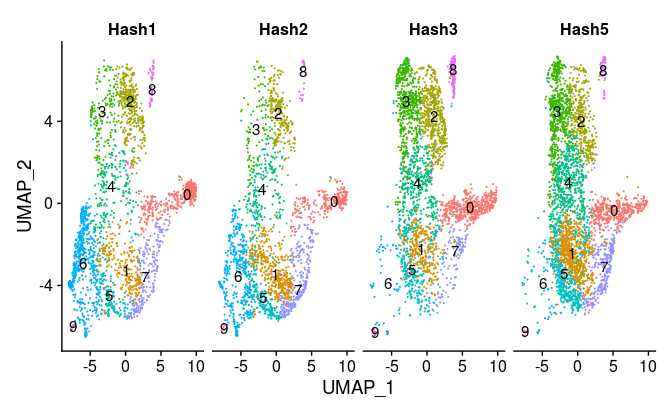

```r
DimPlot(dcSubReg, split.by = \HTO_maxID\, label = TRUE, pt.size = 0.1) + NoLegend()
```

**!!skip this sections, see v6.1!!**

# Clusters:

use ARCHS4 Tissues and Mouse Gene Atlas on ENRichr, look at individual genes

| # | Prof | Cell type | Genes | Datbase | Confidence Fold change |
| --- | --- | --- | --- | --- | --- |
| 0 | ++ | pDC | SiglecH/Ccr9/Bst2/IL7R |  | high |
| 1 | - | HSPC1 | Histone genes |  |  |
| 2 | + | cDC2 | MHC-II Ciita |  | high |
| 3 | - | Mono | Adgre1, Cd14, Ccl9 |  | high |
| 4 | + | Progenitor(GMP/MDP) | Proliferation gene |  |  |
| 5 | - | HSPC2 (Neutro) | Cell cycle | Archs4 |  |
| 6 | + | Neureo | Mpo, Elain |  | high |
| 7 |  | HSPC3 (T blast) | T cell |  |  |
| 8 |  | cd8DC |  |  | high |
| 9 |  | Mast cell | Cpa3, Cd200r3, MS4a3, cyp11a1 | high |  |

**!!skip this sections, see v6.1!!**

**!!skip this sections, see v6.1!!**

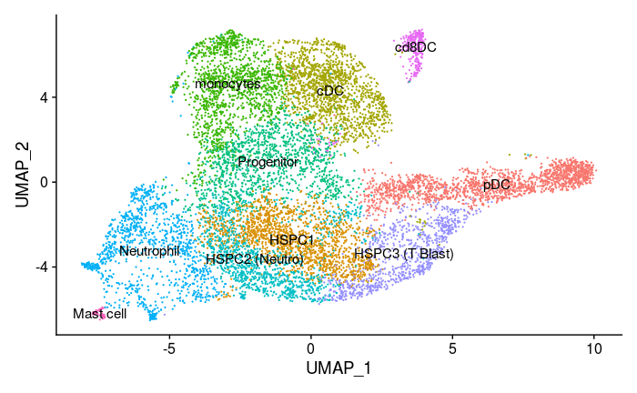

## Slingshot

`r`r

```r
sds <- slingshot(Embeddings(dcSubReg, \umap\), clusterLabels = dcSubReg$seurat_clusters,
                 start.clus = 1, stretch = 2, extend = 'n')
```

```
Using full covariance matrix
```

```
n too large, allowed maximum for palette Set2 is 8
Returning the palette you asked for with that many colors
```

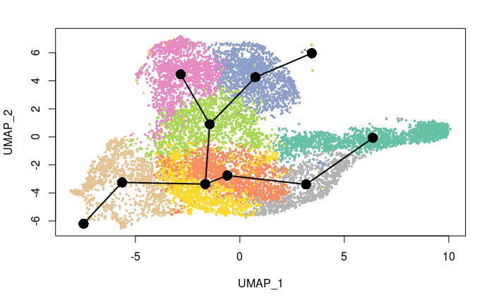

`r`r

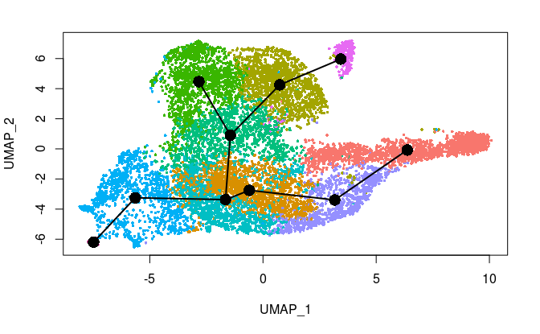

```r
plot(reducedDim(sds), col = cell_colors_clust, pch = 16, cex = 0.5)
lines(sds, lwd = 2, type = 'lineages', col = 'black')
```

`r`r

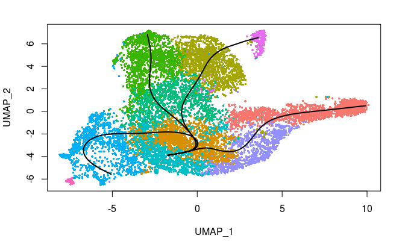

```r
plot(reducedDim(sds), col = cell_colors_clust, pch = 16, cex = 0.5)
lines(sds, lwd = 2, col = 'black')
```

Which cells are in which lineage? Here we plot the pseudotime values for each lineage.

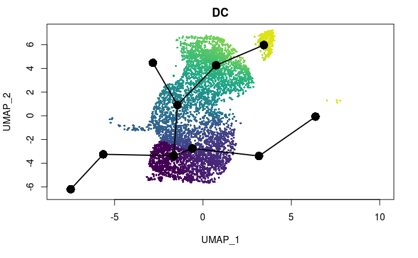

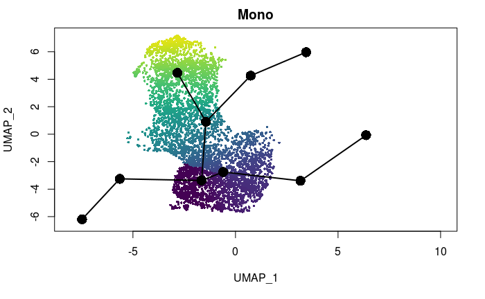

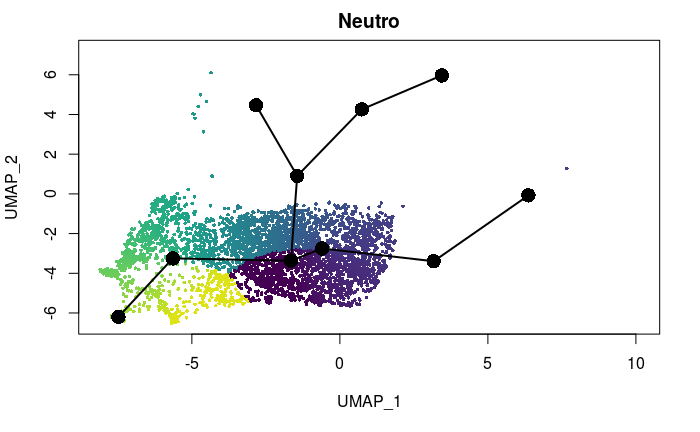

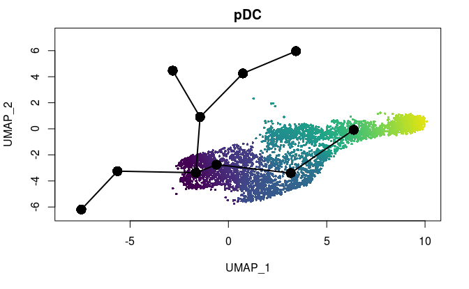